# Abalone Age Prediction

Author

Alex Haddon, Maxine Paredes, Edward Sobczak, and Emma Wolfe

## Summary

Machine learning (ML) models provide a non-invasive alternative to traditional methods of estimating abalone age, which typically require shell sectioning and microscopic analysis. Using the UC Irvine Machine Learning Repository dataset, linear regression was applied to predict abalone age based on physical attributes. After exploratory data analysis, a linear regression model was built using shell weight, diameter, and height as predictors. The model showed moderate predictive power, with an R-squared value of 0.39 and a root mean squared prediction error of 2.5 years. While the model provides reasonable estimates, improvements could be made by exploring more complex ML approaches or additional predictive features.

## Introduction

Determining the age of an abalone is crucial for marine biologists and fisheries management, as it helps assess population dynamics, growth rates, and the sustainability of harvesting practices. Traditionally, an abalone’s age is estimated by sectioning through its shell cone, staining the exposed surface, and counting the growth rings under a microscope. These rings form annually as the abalone matures, with space variations reflecting environmental factors such as food access and environmental temperature (Naylor 2015). However, this method can be invasive and labor-intensive. As a result, researchers have explored alternative techniques, such as using machine learning models.

Researchers have explored alternative techniques to address these challenges, including machine learning (ML) models. By analyzing physical measurements such as length and weight, ML algorithms can predict an abalone’s age without invasive procedures. For instance, a study utilized various machine learning algorithms, including linear regression, logistic regression, K-Nearest Neighbors (KNN), Decision Tree, Random Forest, and Support Vector Machine (SVM), to predict abalone age based on these physical attributes. The comparative performances of each model were assessed using appropriate performance indicators such as precision, recall, or F1-score (Guney 2022).

## Research Question

Can abalone age be predicted and which features are most strongly correlated?

**Dataset Description** This dataset was sourced from the UC Irvine Machine Learning Repository and it was donated on November 11, 1995. It contains various physical and biological attributes of abalone including: Sex (categorical): the biological sex of the abalone, represented as M (male), F (female), or I (infant) Length (continuous): the longest shell measurement, recorded in millimeters (mm) Diameter (continuous): the measurement perpendicular to the length, also in mm Height (continuous): the vertical height of the abalone with its meat still in the shell, measured in mm Whole weight (continuous): the total weight of the abalone, recorded in grams (g) Shucked weight (continuous): the weight of the abalone’s meat after it has been removed from the shell, in g Viscera weight (continuous): the weight of the gut after bleeding, in g Shell weight (Continuous): The weight of the dried shell after removal, in g

## Methods and Results

The first analysis step is to load necessary packages and set the working directory.

The second analysis step is to read in the dataset from the internet. In our case, the Abalone dataset from the UCI Machine Learning Repository, and is stored in a zipped folder. The following code reads in the data and downloads it to the `data` folder of the working directory.

The abalone dataset has 9 variables, 8 of which are numerical, and one of which is characters. All of the numerical values (with the exception of rings) have been divided by 200 for scaling purposes, which we are reversing for interpretability.

The variables are as follows:

- **sex**: [character] describes the sex of the abalone, defined as M (male), F (female), or I (infant)
- **length**: [double] the longest shell length of the abalone in millimeters
- **diameter**: [double] the shell measurement perpendicular to the length in millimeters
- **height**: [double] the shell height (with meat) in millimeters
- **whole_weight**: [double] the whole weight of the abalone in grams
- **shucked_weight**: [double] the weight of the meat in grams
- **viscera_weight**: [double] the gut weight after bleeding in grams
- **shell_weight**: [double] the weight of the dried shell in grams
- **rings**: [double] the age of the abalone in years minus 1.5

Since the `rings` variable gives the age minus 1.5 years, we are creating an age variable that will be our target variable for analysis.

The final cleaning step is splitting the data, which is done using a 70/30 training/testing split. `sex` is removed as a variable because it is not numeric, and its categorical nature makes it more difficult to transform into a numeric variable. `rings` is also removed because we now have the more appropriate age variable.

## Exploratory Data Analysis

Now, preliminary analysis is run on the training data, and visualizations are created. These visualizations are useful for determining the best predictors for linear regression in the dataset.

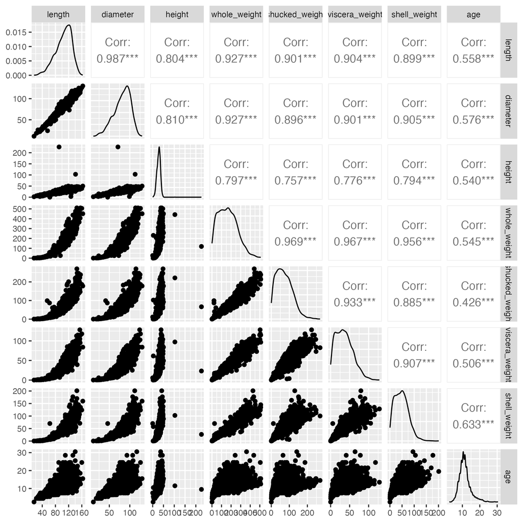

```r
knitr::include_graphics("../output/images/correlation_plot.png")
```

Therefore, the final predictors of the dataset are `shell_weight`, `diameter`, and `height`, while the response variable is `age`.

| variable | mean | median | variance | minimum | maximum |
| --- | --- | --- | --- | --- | --- |
| age | 11.42779 | 10.5 | 10.38061 | 2.5 | 30.5 |
| diameter | 81.38227 | 84.0 | 398.99281 | 11.0 | 130.0 |
| height | 27.87201 | 28.0 | 75.69330 | 0.0 | 226.0 |
| shell_weight | 47.71520 | 46.0 | 787.04570 | 0.3 | 201.0 |

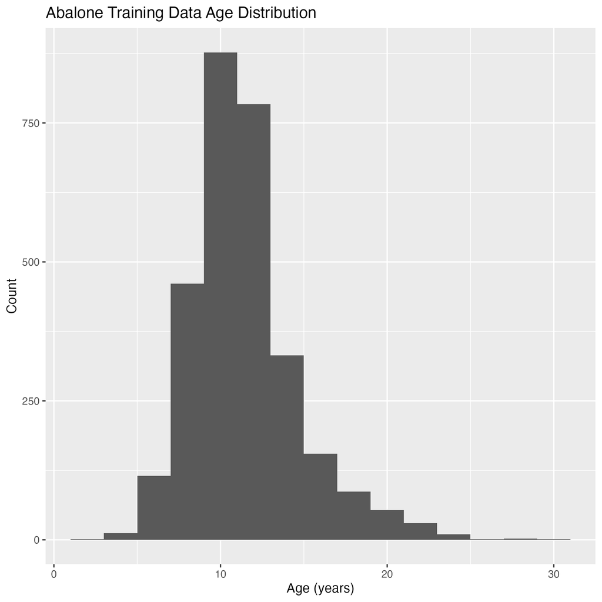

Histogram of the age of abalones in the training data. The peak is around 10 years of age and the curve is slightly right-skewed.

```r
knitr::include_graphics("../output/images/age_histogram.png")
```

Now that we have an idea of what the training data looks like, we can build our linear regression model. We will do so using the `linear_reg()` function from the tidymodels package.

Our last step is to predict the testing data and examine the RMSPE and R-squared value of the model.

Prediction metrics for the linear regression model. `rmse` means Root Mean Squared Prediction Error, `rsq` means R-squared value, and `mae` means Mean Absolute Error.

[output not shown]

The last step in our analysis is to visualize the results, which we have chosen to do using the shell_weight variable, as it has the highest coefficient in the linear model.

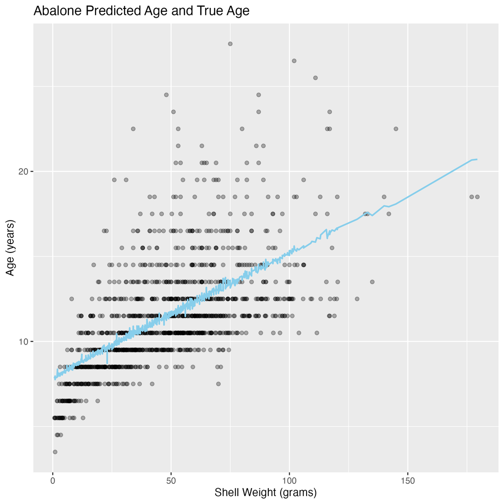

Graph of abalone age (y axis) vs shell weight in grams (x axis). The true ages are plotted as transparent black points, while the predicted ages are plotted as a blue line. While this is a linear model, the line is not perfectly straight as there are other variables influencing the age.

```r
knitr::include_graphics("../output/images/abalone_predicted.png")
```

## Discussion

Essentially, using less costly, less invasive, and less complicated methods to determine abalone age is crucial for the industry and the environment because abalone age is positively correlated with economic value (Muhammad (2019)). Additionally abalone growth rates are variable in aquaculture which makes production difficult and inconsistent (Kho (2023)). Machine learning can be used to advance this industry and help protect abalone populations with non invasive measurements. Other machine learning methods such as Artificial Neural Networks (Muhammad (2019)) have been used to predict abalone age which could be a future step in advancing our model.

The use of machine learning to predict abalone age could be the future for the abalone industry. The future of this research is finding a machine learning model that can be used globally to revolutionize how we determine the age of abalone. There could also be different models developed for wild abalone vs those grown using aquaculture methods for harvesting. Finally, going beyond the abalone industry perhaps there are other mollusc industries that could benefit from similar processes to predict age for harvest.

## References

DFO. 2008. “Northern Abalone.” 2004/053. DFO Science Stock Status Report.

Hossain, Md. Mobarak, and Md Niaz Murshed Chowdhury. 2019. “Econometric Ways to Estimate the Age and Price of Abalone.” Department of Economics, University of Nevada, Reno.

Kho, et al., Khang Hee. 2023. “Age-Dependent Growth-Related QTL Variations in Pacific Abalone, Haliotis Discus Hannai.” *International Journal of Molecular Sciences* 24 (17): 13388. https://doi.org/10.3390/ijms241713388.

Muhammad, et al., Faiz Misman. 2019. “Prediction of Abalone Age Using Regression-Based Neural Network.” In *2019 1st International Conference on Artificial Intelligence and Data Sciences (AiDAS)*, 23–28. https://doi.org/10.1109/aidas47888.2019.8970983.